# ¿Existe Alguna Relación Entre Las Muertes Por Accidentes Automovilísticos Y El Índice De Fragilidad De Estados?

Luis Manzano - Juan Cabral - Emiliana Alvarez - Antonio Vitolla - Michel Lehmann

2022-07-27

## Introducción

El proyecto por realizar tuvo como finalidad analizar las muertes por causa de accidentes automovilísticos en relación del índice de estados frágiles, o como se denomina en inglés Fragile State Index. Se tiene la idea que pueda existir una relación en que mientras más alto sea el índice, es decir mientras el país se considere “frágil” en base a sus instituciones nacionales, exista una mayor cantidad de muertes.

Las Interrogantes que se tomarían en cuenta son: 1. ¿Existe una relación directa entre el Fragile State Index y la cantidad de muertes de los países? 2. ¿Qué ocurrió con la variación porcentual de muerte a causa de accidentes automovilísticos si hay una variación negativa con el Fragile State Index? 3. ¿Se podría confirmar que los países con bajo índice de Fragilidad de Estado son aquellos con menos muertes a causa de accidentes automovilísticos?

Para el proyecto se buscó encontrar un patrón en los resultados de accidentes de tránsito. Al analizar el tópico a tratar se puede intuir que existen al menos dos patrones. El primero siendo que los países con mayores accidentes tienen una tendencia a ser países con fragilidad en sus instituciones. Al mismo tiempo, algunos de los países con menores accidentes de tránsito son aquellos que tenían menor infraestructura y desarrollo. A raíz del patrón observado, se tomó interés en evaluar si esos patrones influyen o no en los accidentes de tránsito, entendiendo que al evaluar Latino América hay variables que van más allá de variables políticas que pueda hacer un estado. Por otro lado, se tiene que entender que en Latino América actúan variables como el nivel de cultural de ingerir alcohol. En ese sentido, el trabajo busca definir si estás variables que no se pueden calcular afectan tienen algún impacto o tiene un peso más importante a la fragilidad del estado.

## Metodología

- Paquetes por utilizar son los siguientes:
1. Library(openxlsx)
2. Library(tidyverse)
3. Library(readxl)
4. Library(dplyr)
5. Library(ggplot2)
- Limpieza de tabla de datos
- Unión de Ambas Tablas
- Realización de diferentes cálculos necesarios para un mayor análisis
- Realización de gráficos para mejor visualización de los datos
- Análisis de gráficos y diferentes cálculos obtenidos

## Descripción de los Datos

Se ha extraído una tabla de datos de la Organización Panamericana de la Salud (OPS). Esta tabla ya se encuentra limpia (limpieza realizada en la asignación anterior) y está compuesta por países del continente americano, la subregion, el año, y los valores de *“Male”* y *“Female”*, los cuales pertenecen a un ratio de muertes por *Road Injury*, es decir, cantidad de muertes totales sobre cada 100.000 habitantes.

Por otra parte, estos datos se van a contrastar con otra tabla de datos extraída de la página de [Fragile State Index](https://fragilestatesindex.org/), la cual estará compuesta por los índices de fragilidad de estados entre los años 2006 y 2016. Este índice representa al valor total de la suma de diferentes indicadores como: Amplia corrupción y comportamiento delictivo, incapacidad para recaudar impuestos o recurrir al apoyo de los ciudadanos, etc.

A continuación se presentará el inicio y el fin de la tabla de datos.

```r
head(road_fragile)
```

```
## # A tibble: 6 x 11
## # Groups:   Country [1]
##   ABB   Country   `Subregion name` Cause        Year Age       Male Female index
##   <chr> <chr>     <fct>            <chr>       <int> <chr>    <int>  <int> <int>
## 1 ARG   Argentina Southern Cone    Road injury  2007 All-ages    19      6    41
## 2 ARG   Argentina Southern Cone    Road injury  2008 All-ages    20      6    41
## 3 ARG   Argentina Southern Cone    Road injury  2009 All-ages    19      5    44
## 4 ARG   Argentina Southern Cone    Road injury  2010 All-ages    19      5    45
## 5 ARG   Argentina Southern Cone    Road injury  2011 All-ages    21      6    46
## 6 ARG   Argentina Southern Cone    Road injury  2012 All-ages    20      5    46
## # ... with 2 more variables: `%Change_Index` <dbl>, `%Change_male` <dbl>
```

```r
tail(road_fragile)
```

```
## # A tibble: 6 x 11
## # Groups:   Country [1]
##   ABB   Country   `Subregion name` Cause        Year Age       Male Female index
##   <chr> <chr>     <fct>            <chr>       <int> <chr>    <int>  <int> <int>
## 1 VEN   Venezuela Andean area      Road injury  2011 All-ages    60     12    78
## 2 VEN   Venezuela Andean area      Road injury  2012 All-ages    66     12    77
## 3 VEN   Venezuela Andean area      Road injury  2013 All-ages    69     13    75
## 4 VEN   Venezuela Andean area      Road injury  2014 All-ages    65     12    76
## 5 VEN   Venezuela Andean area      Road injury  2015 All-ages    65     12    78
## 6 VEN   Venezuela Andean area      Road injury  2016 All-ages    68     12    81
## # ... with 2 more variables: `%Change_Index` <dbl>, `%Change_male` <dbl>
```

```r
road_fragile[,10:11]
```

```
## # A tibble: 280 x 2
##    `%Change_Index` `%Change_male`
##              <dbl>          <dbl>
##  1            0              0
##  2            0              5.26
##  3            7.32           0
##  4            9.76           0
##  5           12.2           10.5
##  6           12.2            5.26
##  7           12.2           10.5
##  8           14.6           10.5
##  9           14.6            5.26
## 10           17.1           10.5
## # ... with 270 more rows
```

Dentro de la tabla se puede observar dos columnas llamadas “%Change_Index” y “%Change_male”. Las mismas pertenecen a la variación porcentual del Ratio de Muertes de Hombres y la variación porcentual del índice de fragilidad de los estadosñ cálculos realizados de la siguiente manera: ((Valor Observado / Valor Base) - 1) * 100

Es importante resaltar que el valor base equivale al valor del año 2007 de cada país, para poder realizar el calculo, se agrupo por estado; de ser otra manera el cálculo no hubiese sido correcto. Con estos datos se busca mas adelante observar el comportamiento de la variación porcentual a lo largo de los años.

## Análisis

### Tabla 1 y 2

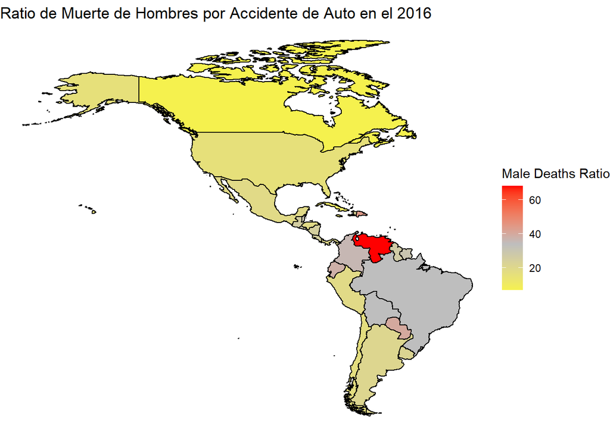

```r
mapa_mundial_hombres
```

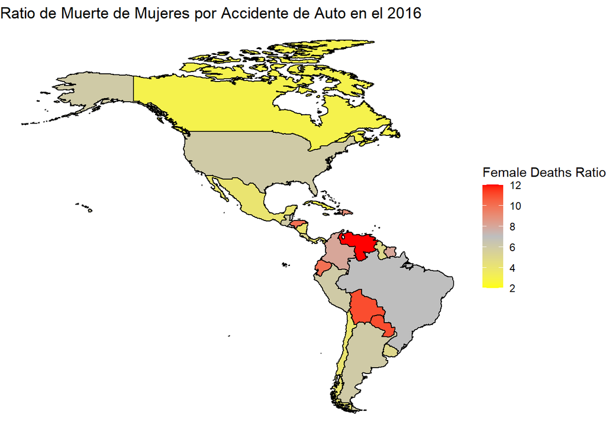

```r
mapa_mundial_mujeres
```

Los gráficos están en base al ratio de muertes automovilísticas de hombre y de mujer, este indicador es igual a las muertes totales por accidentes en autos entre cien mil habitantes.

Podemos observar, que gracias al color con el que país este relleno, se obtiene cual región o territorio tiene el índice más alto, hay que tomar en cuenta que en la gráfica del ratio por muertes automovilísticas, el de género masculino va de 0 a 60, y el del género femenino, de 0 a 12, significando que indicador de las muertes por accidentes de las mujeres es mucho más bajo que el de hombres.

En los gráficos se muestra que la zona de Centroamérica y Norteamérica están de color amarillo, esto nos indica que su ratio no es tan elevado, en cambio en Suramérica, se encuentra Venezuela, que esta coloreada de rojo, significando que es el país que tiene el mayor ratio de muertes por accidentes de toda América.

### Tabla 3 y 4

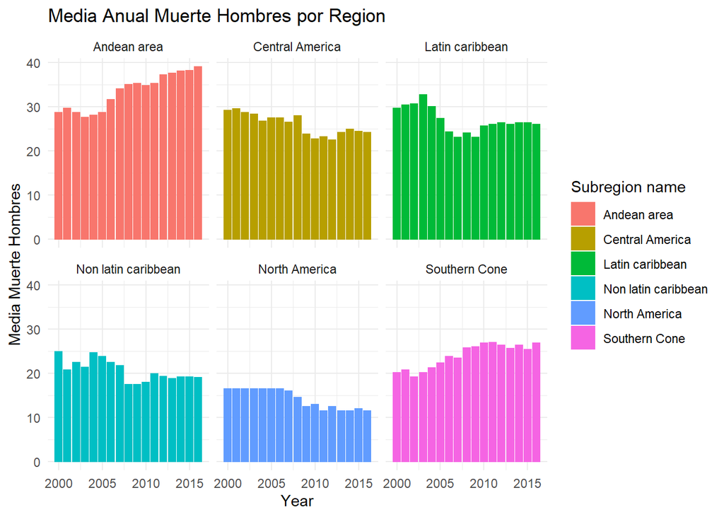

```r
plot_MediaAnualH
```

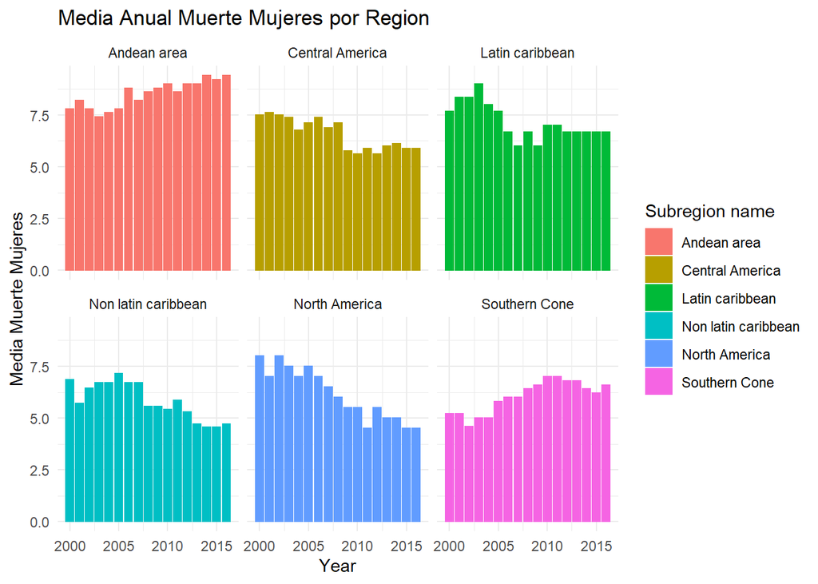

```r
plot_MediaAnualM
```

En estos gráficos de barras se ven las medias de muerte de hombres y de mujeres, por regiones, siendo estas, Área andina, Centroamérica, Caribe latino, Caribe no latino, Norteamérica y el cono Sur.

El Área andina registra las medias más altas, de manera creciente, seguidas por las gráficas, de Centroamérica y Caribe latino, siendo muy parecidas entre si, decrecientes. En el cono Sur también se demuestran cifras altas de media crecientes. En Norteamérica las cifras son muy constantes y bajas, y en la región Caribe no latina son datos bajos con respecto a las primeras cuatro zonas mencionadas y han decrecido desde los años dos mil y han seguido constantes.

### Tabla 5

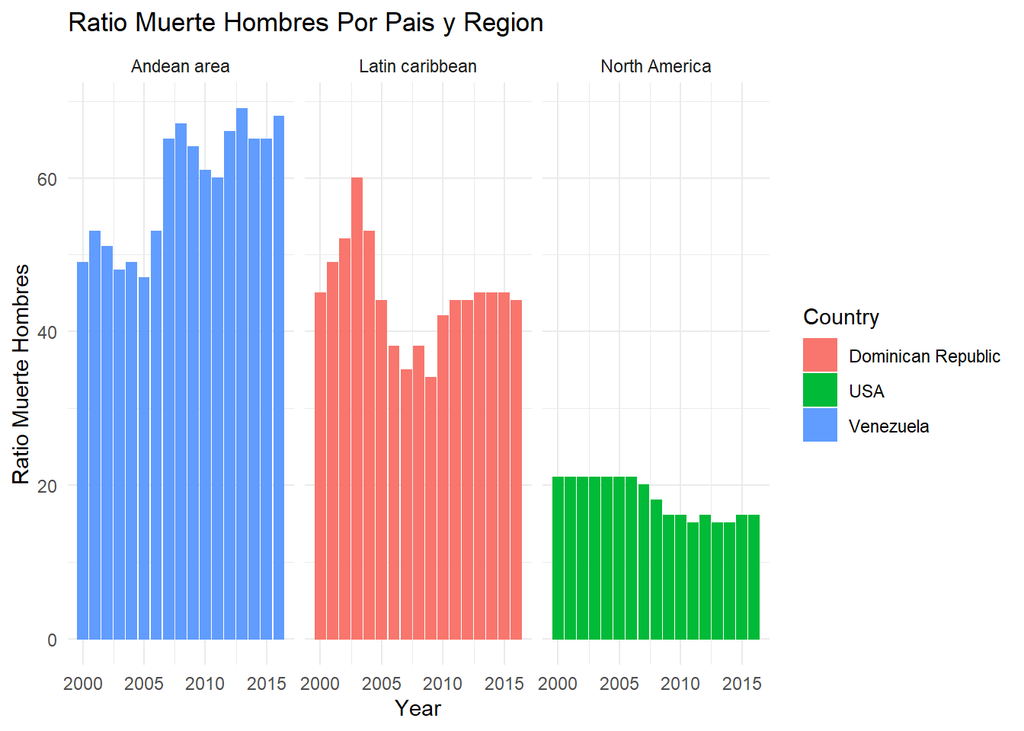

```r
plot_1
```

#### Venezuela, República Dominicana y Estados Unidos.

Se seleccionaron tres países, cada uno correspondiendo a su nivel de ratio y a una región, aquí se intenta lograr una comparación entre tres regiones, Venezuela, representando a el Área andina, Estados Unidos demostrando la zona Norte de América y República Dominicana correspondiendo a los países Caribe latinos.

Aquí se puede observar las diferencias entre los tres países, Venezuela se encuentra con un ratio muy elevado, que continúa creciendo al pasar de los años, en cambio Estados Unidos, a medida que pasa el tiempo, han logrado disminuir este indicador, manteniéndose baja, y Republica Dominicana muestra cifras muy cambiantes, es un país muy fluctuante, sube en el periodo del año 2000 hasta en 2003, 2004, luego disminuye bruscamente hasta el 2010, en donde vuelve a tener un crecimiento, y de aquí en adelante se ha mantenido constante en ese valor.

### Tabla 6

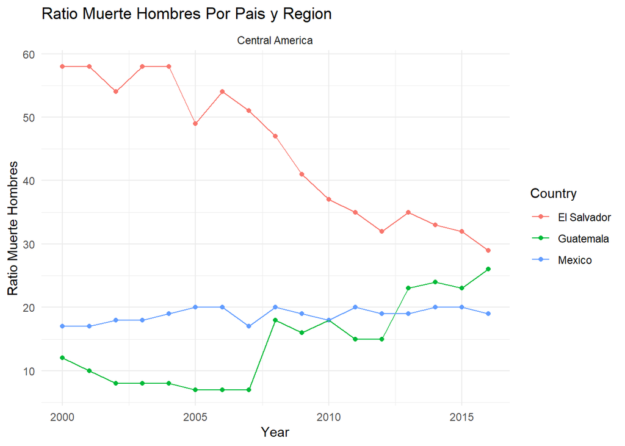

```r
plot_HCA
```

#### Centro América. (México, Guatemala, El Salvador)

Con este gráfico se puede observar el crecimiento y decrecimiento de este ratio en México, Guatemala y El Salvador.

### Tabla 7

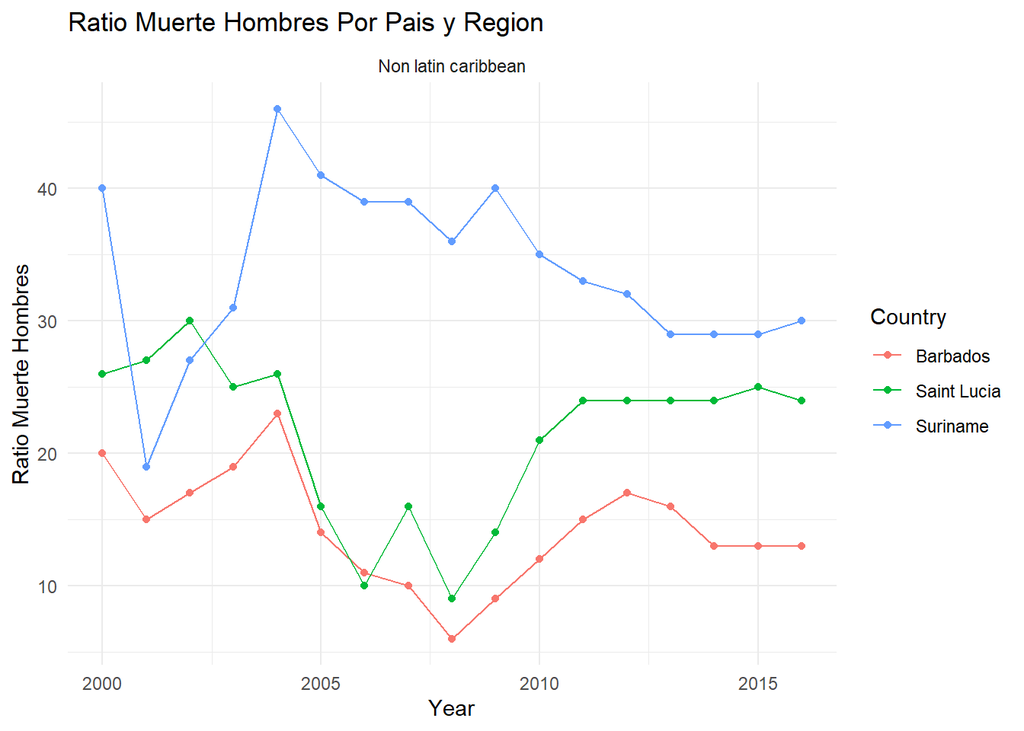

```r
plot_HNLC
```

#### Caribe no latino. (Barbados, Saint Lucia, Surinam)

En este gráfico se aprecia el ratio, a través del tiempo, de los países Barbados, Saint Lucia y Surinam.

Barbados es un país isleño el cual muestra cifras fluctuantes pero bajas, el territorio de Surinam presenta cifras bastante altas en su ratio, y es una cifra un tanto descontrolada con respecto a los años 2000. Las cifras de Saint Lucia se asemejan a las de Barbados, las cifras de la isla son un tanto descontroladas, pero relativamente más altas que las de Barbados.

### Tabla 8

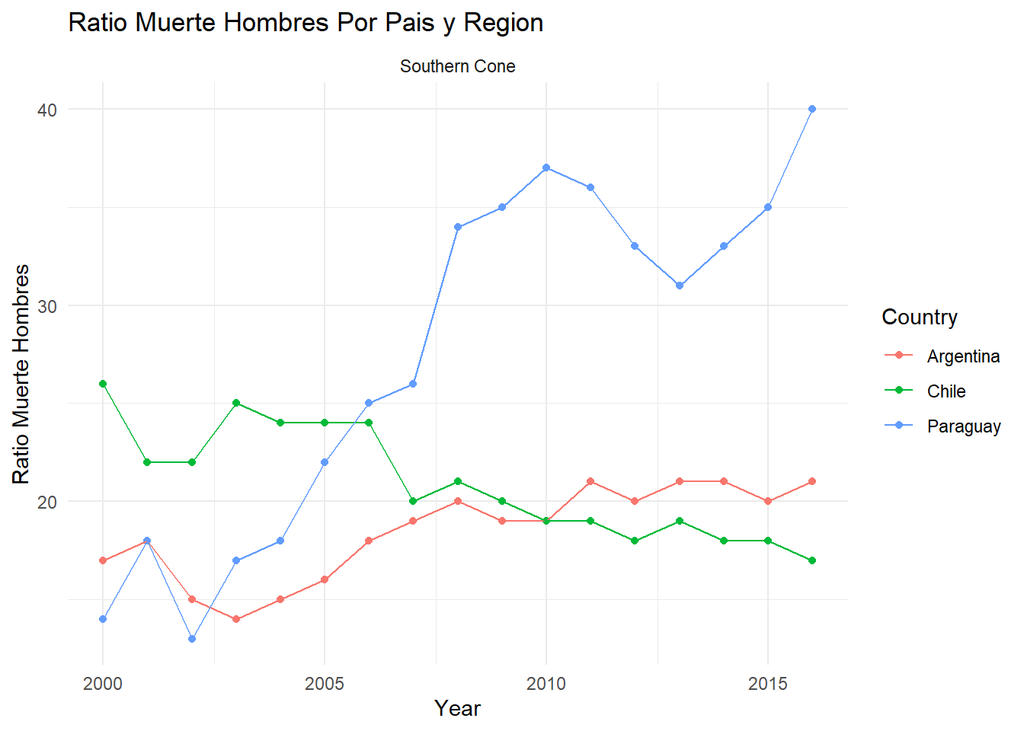

```r
plot_HSC
```

#### Cono sur. (Argentina, Chile, Paraguay)

En el cono sur, específicamente en Argentina, Chile y Paraguay, se muestran cifras un tanto interesantes, esto se debe a que Argentina, con el pasar del tiempo, con base en el 2000, su índice ha ido en aumento, pero sigue teniendo ratios bajos en comparación a otros países, en cambio Chile, sus cifras han ido disminuyendo, significando que han tenido un mejor control sobre estos sucesos. Paraguay, por otra parte, es un país que desde el año 2000 sus ratios han ido en un aumento drástico, terminando, para el 2016 con uno de los ratios más altos, no solo de la región, sino de todo el continente americano.

### Tabla 9, 10, 11 y 12

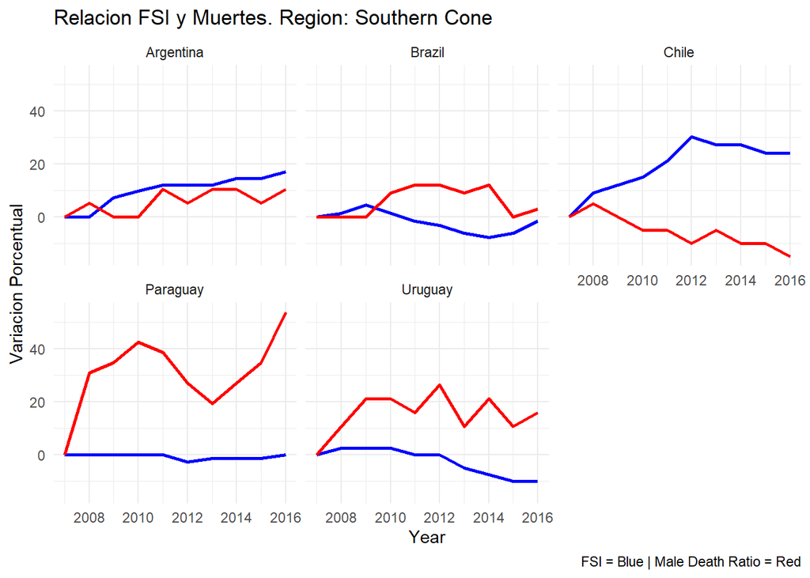

```r
plotISC
```

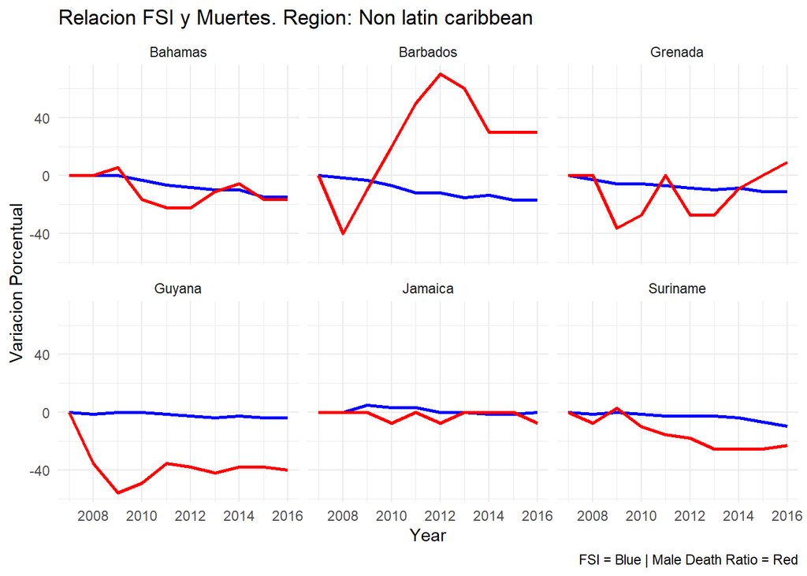

```r
plotINLC
```

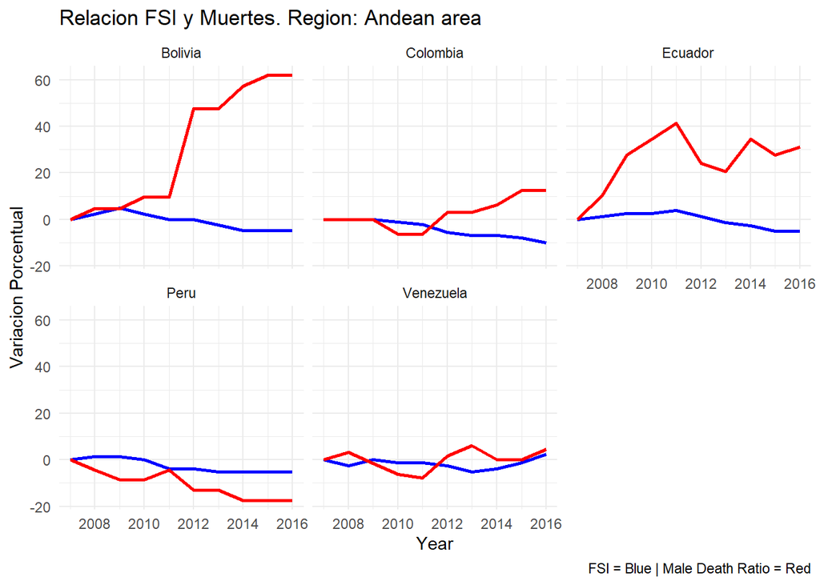

```r
plotIAA
```

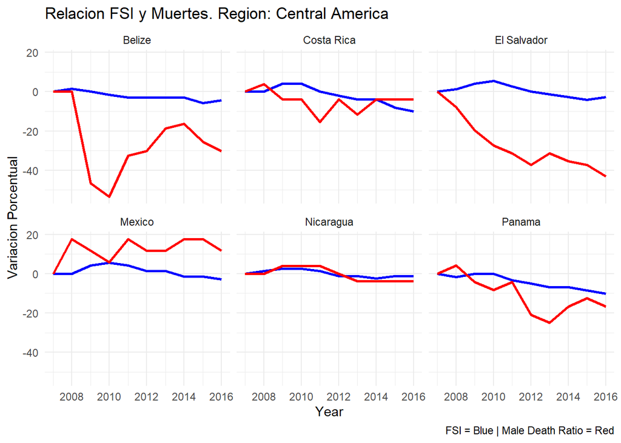

```r
plotICA
```

### Relación FSI/Muertes

#### Centroamérica (Belice, Costa Rica, El Salvador, México, Nicaragua, Panamá)

En Belice y El Salvador la variación de su FSI se nota que ha disminuido un poco, pero su ratio de muertes, su variación porcentual ha disminuido de manera significativa en los últimos años, diciendo que si guardan una relación, en Costa Rica, Nicaragua y México, ocurre algo distinto, su FSI disminuye un poco, pero el comportamiento porcentual de los ratios de muerte aumentan y disminuyen constantemente a través del tiempo, en cambio Panamá es un país el cual su índice de fragilidad ha disminuido bastante, al igual que su variación de ratios de muerte, lo cual demuestra que se relacionan.

## Consideraciones y Limitaciones

Si bien existe una relación entre el índice de fragilidad de los países y las muertes a causa de accidentes de tránsito, no se puede asegurar con un 100% de certeza que es la razón única o principal. El trabajo se ve limitado ya que existen muchas variables que pueden influir en los accidentes automovilísticos. Por tanto, se considera que, para efectos de un mejor resultado, se deben tomar en cuenta otras variables para una mayor profundidad de análisis. Además, para llegar a una conclusión acerca de la relación, es fundamental tomar en cuenta que el contexto de cada país es diferente, y si bien existen países que pueden presentar similitudes en sus variables, cada uno debe tener un análisis individual y es por esto que, un análisis más exhaustivo con otras técnicas de Rstudio y más variables es pertinente.